# part9

```python
import numpy as np
import matplotlib.pyplot as plt
```

```python
np.empty([2, 3], dtype='int')
```

```
array([[         0, 1072168960,          0],
       [1072168960,          0,          0]])
```

```python
np.zeros([2, 3])
```

```
array([[0., 0., 0.],
       [0., 0., 0.]])
```

```python
[0,0,0]                   #0이 들어가 있는 벡터
```

```
[0, 0, 0]
```

```python
[[0,0,0], [0,0,0]]        #2행3열의 list만듦.
```

```
[[0, 0, 0], [0, 0, 0]]
```

[Array]

위의 list는 어디짝에도 쓸모없는 list이다. 계산이 안됨. 계산될 수 있는 array로 만들려면? np library속에 들어있는 함수 중에 Array라는게 있음.

```python
np.array([[0,0,0], [0,0,0]])
```

```
array([[0, 0, 0],
       [0, 0, 0]])
```

2*3행렬처럼 생긴 list를 입력으로 하는 array함수 사용.

위)np.zeros([2,3]) 0으로 되는 matrix array만들어라

아래)list로 입력 적어주고, array로 convert해주어라

-->결과값 똑같음

```python
np.ones([2, 3])
```

```
array([[1., 1., 1.],
       [1., 1., 1.]])
```

*[Ones]: 1로 채워짐 (zeros와 동일 원리)

->1다음에 .은 뭘까? .이 적혀있다는 말은 int가 아니라 float라는 말.

ones라는 함수가 float를 default data type로 취하고 있구나를 알 수 있음.

->dtype = 'int' 하면 .이 사라질 것.

```python
np.ones([2, 3], dtype = 'float64')
```

```
array([[1., 1., 1.],
       [1., 1., 1.]])
```

*Float도 종류가 여러개. Float는 기본적으로 소수점을 의미하며, float뒤의 숫자는 소수점 '몇째 자리'까지 할까?에 대한 것.

아주 정밀하게 하려면 float64사용.(조금의 오차도 허용X)

단점은 숫자를 길게 늘이기 때문에 byte커짐, 메모리 커짐, 공간 많이 사용.

*정확도 VS 데이터 쓰는 양 : 반비례

지금부터 나오는 거 아주 중요!

*[arange 함수]: (numpy에 있는 arange라는 함수) 계산될 수 있는 array로 만들어 줌.

```python
np.arange(5) #for loop 쓸 때 뒤에 in 다음 range쓰는거랑 똑같음.
             #0부터 4까지 순서대로 5개의 index를 만들어준다.
```

```
array([0, 1, 2, 3, 4])
```

```python
np.arange(0, 10)    #0부터 9까지 총 10개의 index를 만들어준다.
                    #10밑으로 까지라는 걸 다시한번 기억!
```

```
array([0, 1, 2, 3, 4, 5, 6, 7, 8, 9])
```

```python
np.arange(0, 10, 2)
#0에서 시작하여 2만큼 뛰면서(증가분) 10미만의 index만들어내자
```

```
array([0, 2, 4, 6, 8])
```

```python
np.arange(0, 10, 2, dtype='float64')
#Data type은 float64로 설정.
```

```
array([0., 2., 4., 6., 8.])
```

<Linspace 함수>

lineal space의 줄임말. (lineal space: 똑같은 간격)

*0부터 10까지 (둘 다 포함!!!) 를 총 6개로 똑같이 나누어 준다.

처음과 끝을 포함한다는 게 포인트.

```python
np.linspace(0,10,6)
```

```
array([ 0.,  2.,  4.,  6.,  8., 10.])
```

```python
x = np.array([4,5,6])   #이렇게만 있으면 벡터가 만들어짐
x
```

```
array([4, 5, 6])
```

```python
x = np.array([[1,2,3], [4,5,6]])#벡터가 아닌 matrix만들고 싶을 때.
x                               #2*3 matrix 만들어짐.
```

```
array([[1, 2, 3],
       [4, 5, 6]])
```

```python
x = np.array([[1, 2], [3, 4], [5, 6]]) #3*2 matrix 만들고 싶을 때.
x
```

```
array([[1, 2],
       [3, 4],
       [5, 6]])
```

<몇차원인지 알기> :마지막에 붙어있는 대괄호 수 = 차원의 수.

벡터:1차원, 직사각형(matrix):2차원

*2차원까지는 list로 표현함.

직육면체(volume):3차원 -표기 가능

*3차원 표기는 대괄호가 세개 나올 것.

1. 대괄호 하나 더 열기
2. ,(comma)하고 똑같은 거 적기
3. 대괄호 닫기

-이러면 차원 늘어남

```python
x
```

```
array([[1, 2],
       [3, 4],
       [5, 6]])
```

```python
x = np.array([[[1, 2], [3, 4], [5, 6]],[[1, 2], [3, 4], [5, 6]]])
x
```

```
array([[[1, 2],
        [3, 4],
        [5, 6]],

       [[1, 2],
        [3, 4],
        [5, 6]]])
```

(위)2차원을 3차원으로 변형시키기. (2차원행렬 2개있으면 3차원)

```python
x.ndim #몇차원인지 알려주는 함수. X라고 먼저 받아야 한다.
```

```
3
```

```python
x.shape #2*3*2의 차원.더 구체적으로 알려준다.
        #괄호안의 숫자가 3개니까 3차원.
        #더 구체적으로는 뒤의 3*2가 아까 2차원짜리 직사각형 의미
        #맨앞의 2는 3*2 그게 두개가 있더라~라는 뜻
        #즉, 3*2의 직사각형이 2개가 있다 를 보여줌
```

```
(2, 3, 2)
```

(위) 제일 큰 괄호 속에 있는 덩어리가 두개 --> 2

```
그 다음 괄호 속에 들어있는 덩어리 세개 -->3

제일 조그만한 괄호 속에 들어있는 숫자 두개 -->2

=> (2, 3, 2)
```

```python
x.dtype #x속에 나오는 숫자들이 어떤 type인지 알고 싶을때.
```

```
dtype('int32')
```

```python
x.astype(np.float64) #뒤의 type으로 바꾸어주어라
```

```
array([[[1., 2.],
        [3., 4.],
        [5., 6.]],

       [[1., 2.],
        [3., 4.],
        [5., 6.]]])
```

```python
np.zeros_like(x)#아까 만든 x의 형태를 유지한 채 숫자만 0으로 바꿈.
```

```
array([[[0, 0],
        [0, 0],
        [0, 0]],

       [[0, 0],
        [0, 0],
        [0, 0]]])
```

```python
x*0 #계산 가능하니까 x라는 array에 0을 곱할수도 있따.
```

```
array([[[0, 0],
        [0, 0],
        [0, 0]],

       [[0, 0],
        [0, 0],
        [0, 0]]])
```

(아래)이제 Plotting이 나옴.

*np라는 큰 library속에 쪼그만 random이라는 subpackage가 있다.

-그 subpackage속에 있는 함수 이름이 normal.

*from 으로는 어떻게 쓸까?

< Normal >

*[Normal] : 정규분포를 만들어주는 함수 (normal distribution)

-종모양의 data 만들어줌.종을 만드는게 아니라, data를 만든다!

-1.평균(mean)값과 2.너비(standard deviation)가 필요하다.

-(평균, 너비, 갯수)의 순서로 적음. ex)(0, 1, 100)

*[Random] : Random한 data가져옴. --나올때마다 다름.

```python
data = np.random.normal(0,1, 100) #random한 data를 가져오는데,
print(data)                       #그 data의 distribution 자체가
                                  #Normal distribution의 형태.
```

```
[-1.52534628 -0.2155318   0.79401419 -0.52847427  0.90752803 -0.26377504
  0.88685174 -2.02181714 -0.68105112  0.4543524   0.53542347  0.414528
  0.78344392 -1.81936065  1.31383938 -1.04900948 -0.72899716 -0.81927068
  0.66783313 -0.78518958  0.85269746 -0.28543854  1.4144832   0.69497851
 -1.05791816 -0.75805806  0.75478431  1.16881772  1.26776815  1.39551478
 -2.03210582  1.33532008 -0.56696047  0.38676633 -0.91317094  0.90371464
 -0.67875509 -0.34534433 -1.86640828 -0.45426121  0.03331181  0.74416646
  0.75735569  2.07073928  1.65068299  0.67719037 -0.13250016 -0.88783862
 -1.03059762 -1.26128676  0.17571655 -2.17392013  0.09000999 -1.29672808
  0.10814834  2.54267782  2.65803564  0.91161865 -0.40424356 -1.63157292
 -2.22042818 -0.55130431  0.32362196 -1.51462548 -0.23810526 -0.04150196
 -0.56558252 -1.17602826  0.29779494  1.01871232  0.48708851 -0.23135781
  0.68648194  1.45168014 -1.47323472  1.54398818  0.01672529  0.5953089
 -1.05091331  0.16177231  0.98981242 -0.63970013 -0.48407334  1.17790292
 -0.01496661  0.47910348 -1.11711759  1.17316669 -0.23160576  0.33895883
 -0.68560495  1.06689005  1.73493654 -0.5602184  -1.70596735  2.60908506
 -0.18130185  0.20881467  0.26546772 -0.13201376]
```

*총 100개의 data가 나옴.

```python
data.ndim #data의 dimension보기
```

```
1
```

```python
data.shape #총 몇개의 숫자가 나왔냐.
```

```
(100,)
```

(아래) 위에 나온 100개의 data를 가지고 실제로 normal distribution을 보이는지 plot할 수 있음.

[1]로 돌아가보자. import matplotlib.pyplot as plt인데,

이말은즉슨 lib속의 sybpackage pyplot을 import해줄건데,

너무 기니까 이를 plt라고 줄여 부르겠다.

[hist]:히스토그램. plt속에 hist라는 함수 가져와서 쓸 것.

(hist.은 항상 bin과 함께 사용)

bin:바구니를 몇 개 사용할 것인가.

-if) bin=10이면? x축에서 0의 좌우로 바구니를 5개씩 정렬.

그리고 위의 data들을 공이라고 생각하고 바구니에 던져 쌓을 수 있음.

그렇게 만들어진 그래프가 histogram.

-입력으로는 아까 np에서 불러온 계산 가능한 array를 취함.

```
[-0.29585574 -1.09727126  1.08311737  0.98079699  0.89295951  0.72927969
 -1.67711058  0.3139507   1.21937439  0.77478935  0.64314958 -0.66171581
  0.66372265  1.91761071 -0.33491392  0.90646607 -0.63484844  2.14478906
 -1.9721273   1.30882908  2.89792874 -0.23459329  0.41752758 -1.06822154
 -0.84392101  0.41868998 -0.23152807 -1.54603013  0.6504961   3.1611992
  0.3011593   1.24605731 -1.15114627 -1.37477573 -0.48077768 -0.48183001
  0.2859789  -0.51137049 -1.26572204  0.07096271 -0.28090432 -0.87780751
  0.46144465 -1.9555821   0.02867693 -1.50837421  0.57984366 -1.84967553
 -0.93781378 -1.39044606  0.38756344 -0.46783623 -2.25670506  0.73037289
 -0.48816341 -0.93117769  0.61017551  0.80398889 -0.17367772  0.98059407
  0.69468807 -1.02540755 -0.79090318 -0.75553982  1.42832662 -0.65908427
  1.47101277  1.91308083 -0.63392521 -1.25590584 -0.67663542  0.41234476
 -0.14623111 -0.94801231  0.79457157  0.52950034 -1.12986791  1.04105913
  1.11796711 -1.24048673 -1.43405518  0.0361431   1.95530302 -0.68821782
 -1.06945176 -0.77641664  0.011592    0.44493109  0.30797013 -0.06313544
  0.75948445  0.58675327 -0.03084704  0.90239744  0.22539123 -0.16598529
 -1.12505815 -1.49679704  0.12864533 -0.67990532]
```

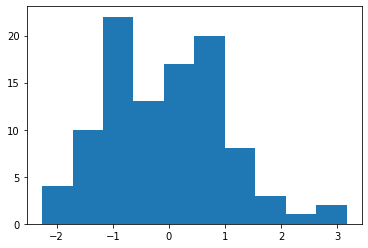

```python
data = np.random.normal(0,1, 100)
print(data)
plt.hist(data, bins=10)
plt.show()
```

y값에 해당하는 것은 무조건 0을 포함한 자연수값이 나와야 함.

why? "몇 개"인지를 말해주는 값이니깐. data는 총 100개!

1차원:vector(선)짜리 숫자

2차원:matrix(직사각형)짜리 숫자

3차원:volume(직육면체)짜리 숫자, 2차원이 여러장 쌓인거

4차원: 3차원이 여러장 쌓인거

-대괄호 숫자와 차원의 숫자는 동일하다.

```python
x = np.ones([2, 3, 4])  #1로 채워넣기
x
```

```
array([[[1., 1., 1., 1.],
        [1., 1., 1., 1.],
        [1., 1., 1., 1.]],

       [[1., 1., 1., 1.],
        [1., 1., 1., 1.],
        [1., 1., 1., 1.]]])
```

BUT 진짜 숫자들로 채워넣고 싶으면 개별 list을 만들고 np.array로 변환하자!

*< Reshape >

: 말그대로 shape을 바꾸어주는 함수

-형태)Y = x.reshape(-1, 3, 2)

-shape이란? (2, 3, 4) 2by3by4를 의미

-element 갯수란? 2X3X4=24개.

=>총 element갯수 유지하는 내에서만 shape변형 가능.(그렇지 않으면 error)

ex) (1,6,4), (3,2,4) 이런식으로만 바꿀 수 있다.

```python
Y = x.reshape(-1, 3, 2) #-1을 적으면 맞는 수 알아서 넣고 계산해줌.
Y                       #(원래는 4가 정답인데)
```

```
array([[[1., 1.],
        [1., 1.],
        [1., 1.]],

       [[1., 1.],
        [1., 1.],
        [1., 1.]],

       [[1., 1.],
        [1., 1.],
        [1., 1.]],

       [[1., 1.],
        [1., 1.],
        [1., 1.]]])
```

```python
np.allclose(x.reshape(-1, 3, 2), Y)

#(2,3,4)->(4,3,2)와 Y가 완전히 일치하냐?
```

```
True
```

*< Randint >

:주어진 범위 내에서 숫자 골라서 matrix만들어라.

-형식: randint(0, 10, [2, 3]) = 0~10에서 숫자 pick up해서 2*3 matrix 만들어라.

(10이 포함되는지 안되는지는 안포함?정의하기 나름.)

*[Random]:말 그대로 2*3의 random을 만들어라

*[np.savez]: 만든 data를 파일로 저장해줌.

-형식: np.savez("test", a, b)

-a,b라는 변수를 저장해줌. 알아서 저장됨.

```python
a = np.random.randint(0, 10, [2, 3])
b = np.random.random([2, 3])
np.savez("test", a, b)
```

```python
!ls -al test* ?  #저장됐는지 확인
```

```
'ls'은(는) 내부 또는 외부 명령, 실행할 수 있는 프로그램, 또는
배치 파일이 아닙니다.
```

위에서 만든 variable a,b를 지우고 싶을 때는?

(원래 cpu 끄지 않는 이상 지워지지 않기 때문에 a, b를 새롭게 쓸 수 없으니깐.)

```python
del a, b
```

```python
%who #지금 available한 variable이 어떤 것이 있느냐
     #memory에 assigned된 variable이 어떤게 있느냐!
```

```
No variables match your requested type.
```

: 저장해둔 파일을 불러오고 싶을 때.

-형태: np.load("파일명적기")

-test.npz : variable들을 담아서 file로 저장해놓은 상태

내일 컴퓨터를 켜서 load해내고 싶을 때 load함수

```python
npzfiles = np.load("test.npz")  #npzfiles대신 a이런거 적어도 OK
npzfiles.files
```

```
['arr_0', 'arr_1']
```

```python
npzfiles['arr_0']   #a라고 assign했던 variable이 불러져나옴.
                    #위 칸에서 나온 이름을 [ ]안에 넣으면 된다.
```

```
array([[3, 5, 9],
       [2, 7, 7]])
```

```python
npzfiles['arr_1']   #b값이 불러져 나온다.
```

```
array([[0.86547825, 0.64762837, 0.49336854],
       [0.0830866 , 0.84001884, 0.7497259 ]])
```

<regression.csv>

-csv (comma separated values): 모든 게 comma로 분리되어있음.

-엑셀에서 csv를 부르면 첫번째 column에 x나오고 밑에 숫자 주르륵~

-엑셀에서도 불러지는 format이고, text로 우리가 제일 많이 쓰는 format.

-github에 올려짐.

-data를 서로서로 전달할 때 파일로 주는 방법 중 하나이다.

-지금 현재 이 파일이 있다면 np.loadtxt("regression.csv")이렇게 불러옴.

[delimiter] :분리시키는 기준

-delimiter="," : ","(comma)로 분리한다.

[skiprows] : data에서 뺄 row 선정.

-skiprows=1 : 첫번째 row(X,Y)는 data로 안 쓸거다.

[dtype] : data type에서

-dtype={'names': ("x", "y"), 'formats':('t', 't')})

---첫번째꺼는 이름 x로, 두번째꺼는 이름 y로

---format들은 둘다 float으로 설정 해 주겠다. (i로 하면 int)

```python
data = np.loadtxt("regression.csv", delimiter=",", skiprows=1, dtype={'names':("x", "y"), 'formats':('t', 't')})
```

[output not shown]

(아래)

[np.savetxt] : 위에서 쓴 data를 저장하고 싶을 때, 누구한테 주고 싶을 때

-형식: np.savetxt("regression_saved.csv", data, delimiter=",")

```
    ("저장될 파일 이름", data, delimiter="분리기준")
```

```python
np.savetxt("regression_saved.csv", data, delimiter=",")
!ls -sl regression_saved.csv
```

```
'ls'은(는) 내부 또는 외부 명령, 실행할 수 있는 프로그램, 또는
배치 파일이 아닙니다.
```

4.INSPECTING

-np의 subpackage random 속의 random이라는 함수 사용하면 random data가 만들어지는데,

이 random data의 shape을 [5,2,3]으로 결정.(3차원의 matrix)

```python
arr = np.random.random([5,2,3])
#arr이라는 변수에 [5,2,3]모양의 random한 3차원 matrix을 넣어줌.
```

-위의 data의 정보들을 뽑아 내 보자.

```python
print(type(arr)) #type출력 : numpy가 만들어낸 n dimensional array
print(len(arr))  #len(길이)출력 : 맨 앞의 숫자 5
print(arr.shape) #shape : (5,2,3)그대로 나옴
print(arr.ndim)  #dimension: 3차원.
print(arr.size)  #size: 5*2*3 = 30. 총 element의 갯수
print(arr.dtype) #dtype: default로 설정된거 나옴.
```

```
<class 'numpy.ndarray'>
5
(5, 2, 3)
3
30
float64
```

5.1 Arithmetic

-a=np.arange(10) : 이렇게 10(숫자 하나)만 넣으면 0~9까지 index 나옴.

-a=np.arange(1,5) : 1부터 5직전까지의 1,2,3,4 index나옴.

```python
a = np.arange (1,5) #1부터 5 직전까지의 index만들어냄.
b = np.arange (9, 5, -1) #9부터 5까지 -1의 increasement로 index.
```

```python
print(a - b)
print(a * b)

#a, b모두 np array이기 때문에 계산이 가능한 상태. (더.빼.곱.나)
```

```
[-8 -6 -4 -2]
[ 9 16 21 24]
```

5.2 Comparison

[Reshape] :

(a)

-np.arange(1, 10):1~9까지의 9개 index (1차원)

-reshape(3,3) : (3,3)의 2차원으로 reshape.

*reshape 전후 모두 9개로 숫자 맞추어 주어야 가능함.

(b)

-np.arange(9, 0, -1): 9부터 1까지 -1씩 늘어가면서 index (1차원)

-reshape(3,3) : (3,3)의 2차원으로 reshape.

```python
a = np.arange(1, 10).reshape(3,3)
b = np.arange(9, 0, -1).reshape(3,3)
print(a)
print(b)
```

```
[[1 2 3]
 [4 5 6]
 [7 8 9]]
[[9 8 7]
 [6 5 4]
 [3 2 1]]
```

```python
a == b #같냐?(두 개 비교)각각에 대해 비교했을 때 5만 같고 다 다름.
```

```
array([[False, False, False],
       [False,  True, False],
       [False, False, False]])
```

```python
a > b #a가 b보다 크냐? 어떤 건 작고 어떤 건 크다.
```

```
array([[False, False, False],
       [False, False,  True],
       [ True,  True,  True]])
```

*(주의): 두 개의 dimension과 shape가 완전히 일치해야 비교할 수 있다.

5.3 Aggregate (sum, min, max, median, std)

-지금 현재

```python
a        #지금 현재 a에 이게 담겨있다.
```

```
array([[1, 2, 3],
       [4, 5, 6],
       [7, 8, 9]])
```

```python
a.sum() #a에 있는 숫자 다 더하자.
#방식1)
#a라는게 벌써 numpy로부터 만들어진 산물이라서
#a라는 자체가 이미 np. 그래서 a.sum이라고 바로 사용 가능.
#그럼에도 불구하고 함수니까 괄호()써줘야됨.
#그대신 자기자신 넣는거니까 괄호 속에는 아무것도 적을 필요X.
#이렇게 쓸 수 있는 이유: np가 만들어냈기 때문!
```

```
45
```

```python
np.sum(a)
#방식2)
#np속에 들어있는 sum이라는 함수를 쓰자.
#그런데 뭘 sum으로? a를.
#(방식1과 2는 완전히 동일하다)
```

```
45
```

*a는 2차원 (3*3)

-첫번째 차원에 해당하는 게 : 가로행

-두번째 차원에 해당하는 게: 세로열

```python
a.sum(axis=0), np.sum(a, axis=0)

#몇번째 차원에서 sum을 할 것이냐?
#0이 첫번째니깐 첫번째 차원의 관점에서 실행.
#(위에서 아래로 찍어눌러서 합 구하기)
```

```
(array([12, 15, 18]), array([12, 15, 18]))
```

```python
a.sum(axis=1), np.sum(a, axis=1)

#axis=1은 두번째 차원 (0부터 시작이니깐!)
```

```
(array([ 6, 15, 24]), array([ 6, 15, 24]))
```

[Broadcasting]: reshape이 broadcasting임.

```python
a = np.arange(1, 25).reshape(4, 6)
#1부터 24까지를 4*6의 2차원으로 바꾸어 주자.
#np.arange하고 바로 . reshape 해도 동시에 다 작동함.
a
```

```
array([[ 1,  2,  3,  4,  5,  6],
       [ 7,  8,  9, 10, 11, 12],
       [13, 14, 15, 16, 17, 18],
       [19, 20, 21, 22, 23, 24]])
```

```python
a + 100 #전부 +100씩 해주기. #a의 차원은 4*6
```

```
array([[101, 102, 103, 104, 105, 106],
       [107, 108, 109, 110, 111, 112],
       [113, 114, 115, 116, 117, 118],
       [119, 120, 121, 122, 123, 124]])
```

```python
b = np.arange(6)  #b의 차원은 그냥 6.
b
```

```
array([0, 1, 2, 3, 4, 5])
```

```python
a + b  #a의 각 행에 b를 차례로 더해주자.
       #(가로길이 같아서 위에서 아래로 차곡차곡 더해줌)
```

```
array([[ 1,  3,  5,  7,  9, 11],
       [ 7,  9, 11, 13, 15, 17],
       [13, 15, 17, 19, 21, 23],
       [19, 21, 23, 25, 27, 29]])
```

```python
c = np.arange(4).reshape([4,1])
c
```

```
array([[0],
       [1],
       [2],
       [3]])
```

```python
a + c  #세로길이 같아서 왼~오로 차곡차곡 더해줌.
```

```
array([[ 1,  2,  3,  4,  5,  6],
       [ 8,  9, 10, 11, 12, 13],
       [15, 16, 17, 18, 19, 20],
       [22, 23, 24, 25, 26, 27]])
```

*[Sampling rate]: sound라는 게 continuous하게 wave되지만, cpu에서 담을 땐 하나하나 값들로 담김.

이 때, (무한대로 담을 수 없으니깐) 1초동안 얼마나 값들을 빽빽하게/듬성하게 담을건가를 말하는 비율. (간격은 다 똑같음)

ex) sr=10000: 1초동안 총 10000개의 숫자를 담을 것이다.

(1초를 표현하는 벡터값들의 수)

(1초에 위잉하는 sine wave를 몇개의 숫자로 표현 할 것인가?)

(hz:1초에 몇번 떨리는가? per sec이란 말 들어가는 순간 모든 경우에서 hz사용. 몇번 왔다갔다하느냐의 pitch 확인할 때 hz)

(sr때 hz쓰는 건 왔다갔다 하기때문이 아니라 1초에~라는 개념이 있기 때문.)

(44100이 CD음질. 이 이상은 인간의 귀로는 구분이 안됨.)

## PART 10

12/04 Numpy array할 때 다차원의 계산 가능한 array를 만들 수 있다.

1차원)벡터

2차원)직사각형

3차원)직육면체

4차원)생각할순x, but 상상가능

이번엔 sound 어떻게 만드는지!

→sound를 praat으로 분석할 때 pure tone으로 미분되는 거 배움.

→여러 pure tone들이 합쳐져서 복잡한 sound 만들어짐.

→pure tone:sin/cosin rate.

→그런 것들을 영어로 이야기: sinu soidal (cos/sin 곡선)

→phasor: sinu soidal function 만드는 것을 phasor이라고 함.

(sin/cos 다 phasor 됨.)

*sin/cos에 들어가는 입력

sin(), cos() : 그냥 각도(ex:90)이 아니라 radian으로 변형된 값 입력.

*Radian? : 각도(0도~360도)를 0 ~ 2ㅠ로 표현하는 방법.

(720도=360도, 즉 2ㅠ=4ㅠ)

*ㅠ:3.141592~ (무리수. 분수로 표현되지않고 반복되지 않는 수)

*sin function이나 cos function에는 radian값이 입력으로 들어감.

*Cosin 곡선 그리면) Cos(0)=Cos(2ㅠ)=1

-시작(0)(0도)= 2ㅠ(360도): 1

-1/2ㅠ(90도): 0

-ㅠ(180도): -1

-3/2ㅠ(270도): 0

-2ㅠ(360도): 1

*Sin곡선 그리면? (태극문양) Sin(0)=Sin(2ㅠ)=0

-시작(0)(0도): 0

-1/2ㅠ(90도): 1

-ㅠ(180도): 0

-3/2ㅠ(270도): -1

-2ㅠ(360도): 0

↓저 모양을 phasor이라고 함. radian값 많이 넣어주면 계속 왔다갔다 하는 그래프 생김. (0~100ㅠ까지도 넣을 수 있음.)

Q:0~100ㅠ까지 그려주면 총 몇번 반복? __ A: 50번

*(주의)둘다 입력을 degrees 가 아닌 radian으로 받는다!

*radian값을 Cos(θ)라고 적어줌. (theta대신 a라고 적어도 OK)

Q)Cos에서 theta가 3/2ㅠ면? (Cos(3/2ㅠ))

A)0

Q) Sin에서 theta가 3/2ㅠ면? (Sin(3/2ㅠ))

A)-1

한차원 더 높은 phasor 배워보자! < 참고: 오일러 공식 >

<오일러 공식> : e의 θ*i 승 = cos(θ) + sin(θ)* i

-cos과 sin 두개가 동시에 들어가 있다!

-cos(θ)라는 function(함수)에서 입력은 theta.

-오일러 공식(e의 θ*i승)에서도 입력이 θ이다.

*e는 상숫값(자연로그 base. 무리수:2.71~), i는 허수(-1의 제곱근)

→e와 i가 fixed되어있기 때문에 θ(radian값)이 변함에 따라 결과가 달라지는 함수이다.

→f(theta) = e의 θ*i승

→오일러 공식의 모든 수는 숫자이기 때문에 θ를 넣은 결과값도 숫자값으로 나오리라는 추론 가능.

Q)수의 가장 큰 개념은? A)복소수

*복소수: a+b*i (우리가 생각할 수 있는 모든 수 표현 가능)

ex) a=/0, b=0 → 실수 /////// a=0, b=/0 → 허수

*따라서 e가 무엇이든간에 a+b*i꼴로 표현 가능하다.

*왜 굳이 i등장? e θ*i승에서도 i가 포함되었으니까 그 계산 결과도 i가 포함되었을 것이다.

Q) 아래 θ값들을 각각 오일러 공식에 넣어보자

θ=0 : (a=1, b=0) → 1

θ=1/2ㅠ : (a=0, b=1) → i

θ=ㅠ : (a-1, b=0) → -1

θ=3/2ㅠ : (a=0, b=-1) → -i

θ=2ㅠ : (a=1, b=0) → 1

(이렇게 반복됨. 왔다갔다)

*Sin Cos 은 실수기 때문에 그림(wave곡선)으로 나타낼 수 있지만, 오일러 함수의 결과값들은 허수를 포함하기 때문에 새로운 방식으로 나타내야 함. 그래서 복소수 plotting이 필요하고, 이를 복소평면 위에 나타냄.

*복소수 plotting

복소평면 (Complex plain)

▷x축:a, Y축:b 으로 그렸을 때, (1,0) → (0,1) → (-1,0) → (0,-1) 반시계방향으로 이동하는 원이 그려짐.

▷원점에서 각도(theta)를 쟀을 때 0도, 45도, 90도, ~이렇게 각도값으로도 표현됨.

▷오일러 공식에다 theta값에 입력값을 radian으로 넣어주면 복소평면에서 point가 생긴다.

ex) 복소평면에 (0.3, 0.8)을 찍으면 그 값은 0.3+0.8i으로 나온다.

ex) 즉, e의 θ(각도값)*i 승이 있을 때, 그 각도값을 그려서 거기를 (몇,몇)으로 표현하면 저절로 몇+몇i라는 값이 나온다. (계산할 필요 X)

*Vector 의 정의: 숫자열

Q) (0.3,0.8)는 벡터일까? A)그렇다.

*Sin곡선에서는 θ값이 늘어남에 따라 Sin곡선이 오르락 내리락 한다.

*복소평면에서는 θ값이 늘어남에 따라 반시계방향으로 원을 돈다.

# Projection이란?

:flashlight을 비출 때 어떻게 나오냐?

-X축에다 projection: (위→아래) : 좌우로 왔다갔다. (실수관점) (Cos)

-Y축에다 projection: (오→왼) : 위아래로 왔다갔다. (허수관점) (Sin)

- 실수부:a(cos), 허수부:b(sin)

▷실수의 관점에서 보겠다: X축 projection, 좌우 이동

▷허수의 관점에서 보겠다: Y축 projection, 상하 이동

# Projection 왜 이렇게 되나?

-Cos:1부터 시작, Sin:0부터 시작.

▷Cos: 1부터 시작해서 -1까지 왔다갔다 = 복소평면 X축 움직임과 일치

▷Sin: 0부터 시작해서 1(위)과 -1(아래) 왔다갔다 = 복소평면 Y축 움직임과 일치

▶오일러 phasor은 Sin, Cos동시에 갖고있고, 복소수와 오일러 숫자의 특이한 성질 이용해서 우리가 원하는 때에 따라서 projection의 방향을 달리하여 Sin / Cos 선택적으로 볼 수 있다.

*Sin, Cos 모두 입력으로 θ(theta=radian=각도)을 취하기 때문에 Sin+Cos의 결합물 만들어낼 수 있음. (Phasor)

*Praat로 소리 만들어낼 때 phasor 을 define할 때 들어가는 입력 θ 말고 하나 더 필요!

-Pure tone에서 넣는 (진폭도 있음) 또다른 입력값 하나가 Frequency.

*Frequency: 1초에 몇번 왔다갔다하는가? (소리 만들 때 이 개념 필요)

Q) Sin(θ)라고 쓰고 각도값이 변한다고 할 때 시간개념이 들어가는가?

A) 안들어감. (그냥 각도값. 몇바퀴 도는가이지 몇초에 몇바퀴 도는지에 대한 개념은 없음)

BUT)시간의 개념이 포함되어야 우리는 1초에 몇번 왔다갔다하느냐~를 알고 소리의 높이를 결정할 수 있음. →"초당"의 개념을 설정해야 소리의 높이를 구현할 수 있다.

EX)왔다갔다 하는 곡선을 그리고, 어느 구간을 설정하고 '이걸 1초로 한다'라는 과정이 있어야 함. (1초에 3번 왔다갔다)

▶진정한 소리(실체): 각도 개념 + 초당 개념 (반드시 시간의 개념 포함!)

-따라서 Sin(θ):소리의 실체X

```python
# parameter setting (variable 이름은 아무거나 가능)
# (변수 assignment 과정)
amp = 1        # range [0.0, 1.0] (진폭, 1~-1)
sr = 10000     # sampling rate, Hz (얼마나 고해상도의 음질)
               # 1초에 총 10000개의 숫자를 가지고 소리를 표현하겠다
               # (1초에 총 들어가는 time tips)
dur = 0.5      #in seconds (몇초동안 삐- 소리가 나느냐)
freq = 100.0   # sine frequenct, Hz (1초에 몇번 왔다갔다 하느냐)
               # 1초에 총 100개의 태극문양 왔다갔다.
```

*절차적으로 time을 먼저 만들어야 한다. (필요한 만큼 만들어야 함)

t 0.001 0.002 0.003 (dur=0.5니까 0.5까지 만들어야 함)

※Time을 얼마나 잘게 쪼개느냐 : 해상도와 관련.

→0.0001로 만들어야 sr와 일치

→ t 0.0001 0.0002 0.0003 ... 0.5000(끝:duration)

→ sr이 10000이니깐 1초라면 10000개 있을 것. 이 경우에서는 dur=0.5이기 때문에 0.5000까지 표현.

→ 위에서 amplitude 개념은 포함되어있지 X

▶Sr + Dur = Time 개념

-어차피 time도 우리가 계산해야하기 때문에 np개념도 이용해야 한다.

```python
t = np.arange(1, sr+1)  #1에서 10000까지의 index가 만들어짐.
```

↓sr+1=10000개. 만약 duration이 1초라고 하면, 1초동안 저 sr으로 만들어내는 time tig의 수는 같아야 함.1초라면 지금 딱 맞음.

▷sr+1 :10000개 모두 사용

근데 지금은 0.5초인데?

↓어떻게 0.5초를 만드냐? (sr 10000개 다 쓰는게 아니라 5000개만 쓰고 싶다.) **dur 곱해주기.

▷sr * dur (0.5) + 1 : (+1하는 이유는 코딩할 때 맨마지막숫자 안쓰니깐)

▷0.5까지의 time tig이 생긴다. (1 2 3 4 ~ 5000까지.)

▶BUT "time tig"(1~5000 index)이 생긴 것이지 "time"이 생긴 건 아니다.

→0.0001~0.5000초까지 생성됨. (Time을 먼저 만들어 주어야 함!)

```python
# generate time
t = np.arange(1, sr * dur+1)/sr
```

```python
t #t잘 만들어졌는지. array에서 1차원벡터 만들어짐
```

```
array([1.000e-04, 2.000e-04, 3.000e-04, ..., 4.998e-01, 4.999e-01,
       5.000e-01])
```

↑※ 1.000e-04 : 10의 4승분의 1 (1/10000) = 1 * 1/10000

## *2.000e-04(2* 1/10000) ~~~ 4.998e-01(4.998 * 1/10) ~ 5.000e-01(0.5)

*Time이 없으면 절대로 실체의 소리를 만들어낼 수가 없기 때문에 Time을 먼저 만들어야 함!

→그렇다고 Time만 있다고 아무거나 할 수 있는게 X.

→실제로 θ(phase각도값)이 필요함. (Time과 연동시켜서 phase로 바꾸어 주어야 함.)

-(아래) phase만드는 방법

```python
# generate phase
theta = t * 2*np.pi * freq
```

(위에 보기)

- 2*np.pi = 2ㅠ (상수값) (np를 써야 np속의 ㅠ이 정의돼서 계산 가능)
- t *2*np.pi?

(time이 0~1까지 정의되었다고 생각해보자.sr=10000. 그러면 1초에서의 time값은 1. 거기에다 2pi 곱하면 2pi.)

→ 0 ~ 1 에다가 통째로 2pi 곱하기 → 0pi ~ 2pi 가 나온다.

→ = 한바퀴 도는거. (Frequency=1 이었으면 여기까지만 해도 OK)

▷time=1초일 때 Frequency=1바퀴 → time * 2ㅠ → 1바퀴 도는거.(OK)

BUT) 우리는 한바퀴 돌자고 만드는 거 아님.

*Frequency: 총 몇바퀴 만드는가에 대한 개념.

→Freq 곱해주기: 2ㅠ가 1초동안 총 몇개 있어야 하는가?

→Freq=100 : 총 100바퀴를 돌아라.

그렇게 해서 theta 에 넣어줌.

(요약)

1. time 만들기
2. time 에다가 phase 연동시키기 (단순 phase X)
3. time + phase(각도.theta개념) 동시에 들어가야 함.
4. 그리고 나서 밑의 식에 theta를 넣어줌

```python
# generate signal by cosine-phasor
s = np.sin(theta)   #sin도 np함수 써야지 계산 가능함.
```

Q) time(vector.숫자니까)의 size(숫자 몇개있냐) 와 theta의 vector size는 같다?

A) 당연히 같음.

※generate time: t = np.arange(1, sr * dur+1)/sr

※generate phase: theta = t *2*np.pi * freq

→왜 ? time (10000분의 1초 ~ 10000분의 5000초: 총 5000개의 time vector 만들어냄) → 거기다가 *2*np.pi*freq 해서 theta에 들어 있음.

▷똑같은 갯수의 vector가 theta에 들어 있다.

※ generate signal by cosine-phasor: s = np.sin(theta)

▷저기에 theta값을 sin했더니 s에 값이 생김.

↓이걸 밑에서 그래프로 표현함.

# plotting 하는 방법 :

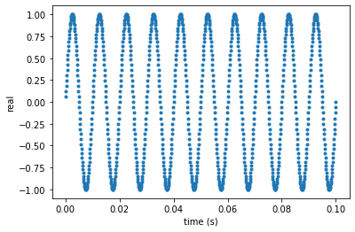

```python
fig = plt.figure()     #lib에서 plt가져옴. 이 방식으로 fig가짐
ax = fig.add_subplot(111)  #fig함수에서 어떤 그림 만들 준비 함.
ax.plot(t[0:1000], s[0:1000], '.') #여기에서 plt(함수사용)하겠다
#plot함수는 2개의 입력값 받음.(x,y입력값 받음?)
#1)time. 근데 위에서 time정의 했으니까 대신에 theta넣어도 OK -X
#2)s(sin의 결과값) -Y
#(세번째 입력값은 .으로 표현하라)
ax.set_xlabel('time (s)')   #label 적는거. (없어도 괜찮은 과정)
ax.set_ylabel('real')
```

↓X축은 말그대로 time.

▷time: 첫번째 ~ 총 5000개 만들었는데 이 그래프에서는 총 1000개만 plotting한다. → (t[0:1000])에서 알 수 있음

▷s: s도 5000개 다 하는게 아니라 1000개만 plotting → (s[0:1000])

(너무 가늘고 빽빽하면 잘 안보이니깐)

▶ timewise: 0.1초까지 등장. X 왔다갔다 하는거 보임.

▶ sin 곡선: 0부터 시작해서 왔다갔다 하는거 볼 수 있음. (Cos은 1부터)

(아래는 왜 오류일까?)

```python
# generate signal by complex-phasor
c = np.exp(theta*1j)  #e에 해당하는게 오일러.
```

```python
fig = plt.figure()
ax = fig.add_subplot(111, projection='3d')
ax.plot(t[0:1000], c.real[0:1000], c.imag[0:1000], ".")
ax.set_xlabel("time (s)")
ax.set_ylabel("real")
ax.set_zlabel("imag")
```

[output not shown]

# < Part 11 >

저번시간에

1)phasor 배움. cos 과 sin phasor 이용하기.

2)오일러 phasor로는 cos sin component 동시에 사용할 수 있음.

이번시간에는 저번시간 복습 위주로.

# Numpy

*From: 제일 큰 lib가 있고 그 밑에 sublib있는거 우선 이해하자.

-형식) from 큰거 import 부를거 이름 as 약칭

```python
from matplotlib import pyplot as plt #plotting할 때 쓰는 lib 부름.
#(=import matplotlib.pyplot로 표현 가능)
from mpl_toolkits.mplot3d import Axes3D
#밑에서 3D plot사용.
from mpl_toolkits.axes_grid1 import make_axes_locatable
import IPython.display as ipd
import numpy as np       #numpy lib import, as는 줄여쓸 때.
%matplotlib notebook
from scipy.signal import lfilter
```

# Phasor

1.여러가지 변수 설정하기

Q) 왜 이런 장치를 미리 해놓냐?

A) 나중에 amp / dur / sr 바꿀 때 저부분만 고쳐주면 결과값 알아서 바뀜.

```python
# parameter setting (미리 변수에다 값 담아놓기)
amp = 1              # range [0.0, 1,0]
sr = 10000           # sampling rate, Hz
dur = 0.5            # in seconds
freq = 200.0         # sine frequency, Hz
```

1. Time 만들기

Q) 왜 time 부터 만들어야 하나?

A) phasor (sin, cos, euler function) 들이 받아들이는 입력이 어차피 각도값 (radian O, time, degree X).

그런데, 각도값만 넣어서는 실체의 소리를 만들어낼 수 없다.

# 1.각도값으로만 Sin 곡선 만들기 (시간X)

-0~2pi까지 만들어서 이를 sin함수에 넣으면 곡선 만들어짐

-sr은 time 개념이 포함된 것이므로 각도 만들 때 고려 X.

1. 각도의 data 먼저 만들기 (0~2pi) ※np.pi라고 써줘야 계산가능.

(np.arange 원래 1만큼 뜀.default니까 따로 설정 , 2pi는 6.28이니까 6까지 나옴)

```python
#각도값만으로 sin 곡선 만들어보자.(0~2pi까지 만들 수 있음)
theta = np.arange(0, 2*np.pi)
theta
#(결과:이 theta 값들을 radian으로 정의함)
```

```
array([0., 1., 2., 3., 4., 5., 6.])
```

1. 이제 위에서 만든 theta값들을 sin 함수에 입력으로 넣어보자.

※np.sin라고 써줘야 계산가능

-위에서 나온 radain(각도)값들을 sin함수에 하나하나 들어가서 총 7개 벡터값들이 나온다. 이것을 s라는 변수로 받고, plot하면 sin 곡선 나옴

```python
s = np.sin(theta)
s
```

```
array([ 0.        ,  0.84147098,  0.90929743,  0.14112001, -0.7568025 ,
       -0.95892427, -0.2794155 ])
```

1. 아까 꺼낸 plt의 sublib에서 figure 이라는 함수 또 꺼내자 (괄호가 있으니까 function) → 이게 fig.
2. fig 라는 함수의 sublib에서 add_subplot 함수를 또 꺼내자 (fig 는 아래 화면 전체를 말함, subplot은 화면 분리를 말함.)
3. ax 는 뭔가?

*아래 fig 태극문양처럼 생김 → sin 함수구나를 알 수 있다.

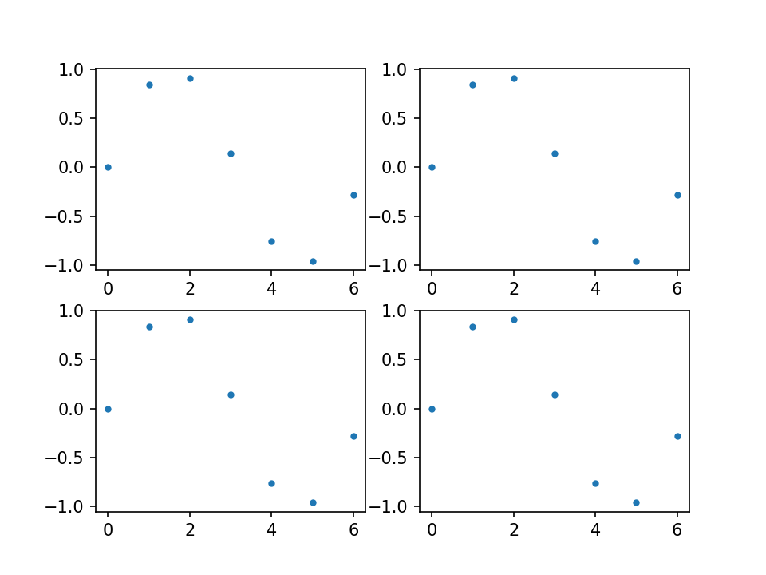

```python
fig = plt.figure()
ax = fig.add_subplot(221) #2*2 (2행2열로 화면분리, 그중에 1번째)
ax.plot(theta, s, '.')  #plotting 하려는 x값,y값 각각 적어주기
ax = fig.add_subplot(222) #2*2 (2행2열로 화면분리, 그중에 2번째
ax.plot(theta, s, '.') #theta:x값(0~2pi각도값), s:y값(3차원의 output)
ax = fig.add_subplot(223) #2*2 (2행2열로 화면분리, 그중에 3번째
ax.plot(theta, s, '.') #서로서로 개수는 corresponding
ax = fig.add_subplot(224) #2*2 (2행2열로 화면분리, 그중에 4번째
ax.plot(theta, s, '.')  #s(y)값은 theta를 sin함수에 넣은 결과값.
```

→ 더욱 빽빽하게 만들고싶다. 아까 np.arange 할때 default를 1만큼 했는데, 이걸 더욱 작게 만들어주면 빽빽한 그래프 표현 가능

```python
# parameter setting (미리 변수에다 값 담아놓기)
amp = 1              # range [0.0, 1,0]
sr = 10000           # sampling rate, Hz
dur = 0.5            # in seconds
freq = 200.0         # sine frequency, Hz
```

```python
theta = np.arange(0, 2*np.pi, 0.1)
theta
```

```
array([0. , 0.1, 0.2, 0.3, 0.4, 0.5, 0.6, 0.7, 0.8, 0.9, 1. , 1.1, 1.2,
       1.3, 1.4, 1.5, 1.6, 1.7, 1.8, 1.9, 2. , 2.1, 2.2, 2.3, 2.4, 2.5,
       2.6, 2.7, 2.8, 2.9, 3. , 3.1, 3.2, 3.3, 3.4, 3.5, 3.6, 3.7, 3.8,
       3.9, 4. , 4.1, 4.2, 4.3, 4.4, 4.5, 4.6, 4.7, 4.8, 4.9, 5. , 5.1,
       5.2, 5.3, 5.4, 5.5, 5.6, 5.7, 5.8, 5.9, 6. , 6.1, 6.2])
```

```python
s = np.sin(theta)
s
```

```
array([ 0.        ,  0.09983342,  0.19866933,  0.29552021,  0.38941834,
        0.47942554,  0.56464247,  0.64421769,  0.71735609,  0.78332691,
        0.84147098,  0.89120736,  0.93203909,  0.96355819,  0.98544973,
        0.99749499,  0.9995736 ,  0.99166481,  0.97384763,  0.94630009,
        0.90929743,  0.86320937,  0.8084964 ,  0.74570521,  0.67546318,
        0.59847214,  0.51550137,  0.42737988,  0.33498815,  0.23924933,
        0.14112001,  0.04158066, -0.05837414, -0.15774569, -0.2555411 ,
       -0.35078323, -0.44252044, -0.52983614, -0.61185789, -0.68776616,
       -0.7568025 , -0.81827711, -0.87157577, -0.91616594, -0.95160207,
       -0.97753012, -0.993691  , -0.99992326, -0.99616461, -0.98245261,
       -0.95892427, -0.92581468, -0.88345466, -0.83226744, -0.77276449,
       -0.70554033, -0.63126664, -0.55068554, -0.46460218, -0.37387666,
       -0.2794155 , -0.1821625 , -0.0830894 ])
```

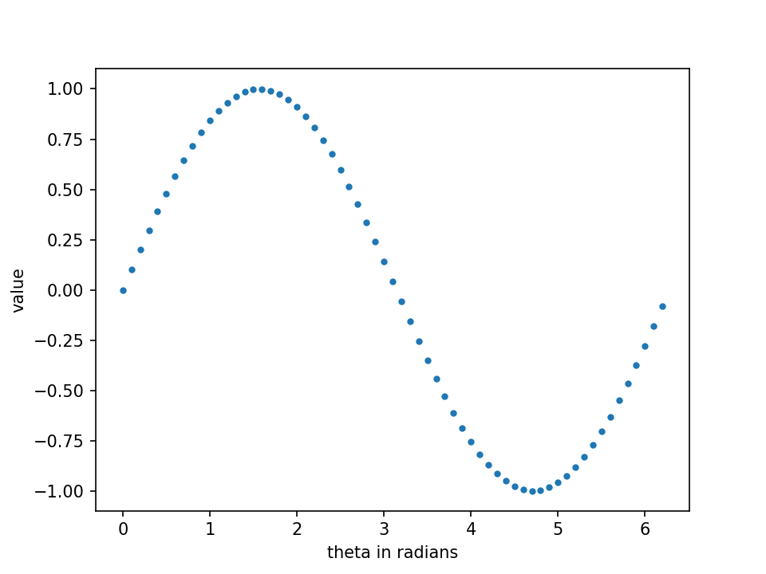

```python
fig = plt.figure()
ax = fig.add_subplot(111) #1*1 (2행2열로 화면분리, 그중에 1번째)
ax.plot(theta, s, '.')  #plotting 하려는 x값,y값 각각 적어주기.
                   # '-' 으로 바꾸면 line으로 나타내어줌
ax.set_xlabel('theta in radians') #X축, Y축 이름 달아주자 (이것도 function)
ax.set_ylabel('value')
```

*Q) 위 그래프는 X 축에서는 equiextance. Y축에서는? 아니다.

A)X 축에서는 등간격, Y축에서는 등간격 X. (곡선, Non-lineal)

*Q) Y축에서도 등간격일 수 있을까?

A) Lineal 한 경우에는 Y축에서도 등간격 OK

ex) y = ax + b 인 경우 (x,y관계가 직선일때) 그걸 제외한 모든 함수는 non-lineal (로그, 지수, 다차함수, 사인함수 등등...)

# 2.시간부터 먼저 만들어서 plotting

*지금까지 한 plotting 에는 시간이 빠져 있지만 실체의 소리를 만들어내려면 time 개념이 들어가야한다. (그래프의 시작~끝이 1초인지, 1년인지 알 수 없다.)

*이제는 시간부터 먼저 만들어보자!

1.time tig의 개수 먼저 만들기 (만약 1초라면 time tig = sr과 같아서 총 10000개)

(※그런데 1초가 아니라면? sr*dur 으로 변경)

2.초로 바뀌려면 /sr (sr로 나누어주기) 해야함. (10000번째가 1초가 됨)

```python
t = np.arange(1, sr*dur+1)/sr
```

3.이제는 time을 기반으로 한 theta 만들어보자.

Q) freq 부분이 없다면?

A) t:1초일때 → 2pi를 곱하면 (freq 없이) → 1초동안에 한바퀴 돈다는 뜻.

*Freq: 몇바퀴 도는지에 관련

※ sr 와 freq 같은 unit(hz)사용하지만 반드시 구분!

*sr: 점(숫자)들이 1초동안 얼마나 많이 나오느냐

*freq: shape 이 몇번 왔다갔다하느냐

```python
# generate parameter
amp = 1              # range [0.0, 1,0]
sr = 10000           # sampling rate, Hz
dur = 0.5            # in seconds
freq = 200.0         # sine frequency, Hz
```

```python
# generate phase
theta = t * 2*np.pi*freq
theta
```

```
array([1.25663706e-01, 2.51327412e-01, 3.76991118e-01, ...,
       6.28067203e+02, 6.28192867e+02, 6.28318531e+02])
```

```python
s = np.sin(theta)
s
```

```
array([ 1.25333234e-01,  2.48689887e-01,  3.68124553e-01, ...,
       -2.48689887e-01, -1.25333234e-01,  3.92877345e-15])
```

*이제 theta, time, s 전부를 가지고 plotting 할 거다.

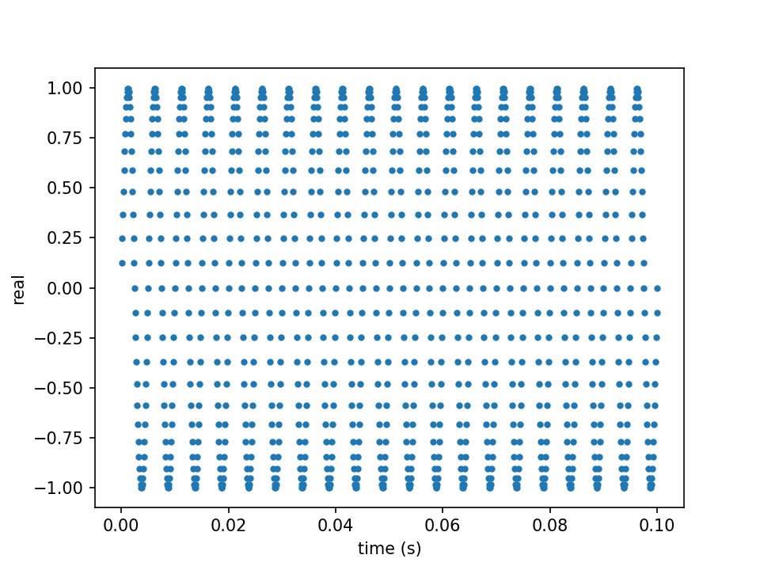

```python
fig = plt.figure()
ax = fig.add_subplot(111)
ax.plot(t[0:1000], s[0:1000], '.') # t 갯수 = s 갯수 해야 점 찍힘.
#대괄호X:모든벡터사용,대괄호OK:일부사용 (t,s)의 2차원 벡터 찍힘.
#점들 갯수 총 = 1000개
#(t, s 전체 사용하면 태극문양 안보이고 그냥 가로선 쭉쭉 그어짐)
ax.set_xlabel('time (s)')
ax.set_ylabel('real')
```

```python
#ipd 함수는 입력으로 2개 받음. 1)c.real, 2)sr
ipd.Audio(c.real, rate=sr)  #sin 의 s 써도 똑같음.
```

[interactive chart not shown]

```python
# Install sounddevice
# 이렇게 해도 소리 나옴 (sd 속에 있는 play 함수 사용)
!pip install sounddevice
#유명하지 않은 프로그램은 먼저 깔아주어야.
import sounddevice as sd
sd.play(c.real, sr)
```

지금까지는 sin , cos phasor 했음

# 오일러 공식 이용한 Phasor

-np.exp(exponation 함수) = 큰 e 라는 숫자

-함수 안에 들어가는게 theta*1j (1j = i)

▷큰 e 의 지수로 theta*i 들어가는 꼴.

(이미 위에서 time, vector 만들어 놓음. 이제 c만 만든거)

(나머지 다 고정, 이제 theta 만 입력으로 넣으면 된다)

```python
# generate signal by complex-phasor (복소수로 범위 확대)
c = np.exp(theta*1j)
c
#하나하나의 값들이 모두 a + bi 의 형태로 구성됨
#복소수는 a,b두개의 정보 (sin은 하나)
#정보량 똑같이 정해주는 수 형태 (e-01j~)
```

```
array([0.9921147 +1.25333234e-01j, 0.96858316+2.48689887e-01j,
       0.92977649+3.68124553e-01j, ..., 0.96858316-2.48689887e-01j,
       0.9921147 -1.25333234e-01j, 1.        +3.92877345e-15j])
```

[figure not shown]

```python
fig = plt.figure() #figure 먼저 만들기
ax = fig.add_subplot(111, projection='3d') #회전체를 3d로
ax.plot(t[0:1000], c.real[0:1000], c.imag[0:1000], '.')
#3d 답게 입력 3개 필요함 (저 한 점이 3차원 벡터 점)
ax.set_xlabel('time (s)')
ax.set_ylabel('real')
ax.set_zlabel('imag')
```

< 복소수의 a,b부분 따로 받아 plot >

*복소수: a(real) + b(imaginary)i

-c.real : a 만 쏙 빼오는 역할 (y축) (projection → cos 1부터시작)

-c.imag : b 만 쏙 빼오는 역할 (z축) (projection → sin 0부터시작)

# <Part 12>

-phasor (시간 없이 theta 값들만 있어도 sin, cos 곡선 만들어지지만, 그것만으로는 실체의 소리를 만들 수 없다)

-소리는 반드시 시간의 개념이 들어가야 함!

-phasor 의 입력(input)은 radian(각도)인데, 거기에 반드시 시간(time)을 연동시켜야 재생됨.

< Amplitude 활용하기 >

: sin/cos wave 의 진폭을 이야기함

: complex wave 의 소용돌이 크기를 이야기함

# 1.Generate signal by cosine-phasor

```python
# generate parameter
amp = 2              # range [0.0, 1,0]
sr = 10000           # sampling rate, Hz
dur = 0.5            # in seconds
freq = 400.0         # sine frequency, Hz
```

```python
# generate time
t = np.arange(1, sr*dur+1)/sr
```

```python
# generate phase
theta = t * 2*np.pi*freq
theta
```

```
array([2.51327412e-01, 5.02654825e-01, 7.53982237e-01, ...,
       1.25613441e+03, 1.25638573e+03, 1.25663706e+03])
```

```python
# generate signal by cosine-phasor (진폭 phasor에 심기)
# 기본형태: -1~1 까지의 진폭의 sin wave
# amp 구현: amp 를 앞에 곱해주면 설정해준 진폭으로 바뀜
# amp 2 니까 진폭 -2~2 로 바뀜.(진폭:2 라고 읽음)
s = amp*np.sin(theta)
```

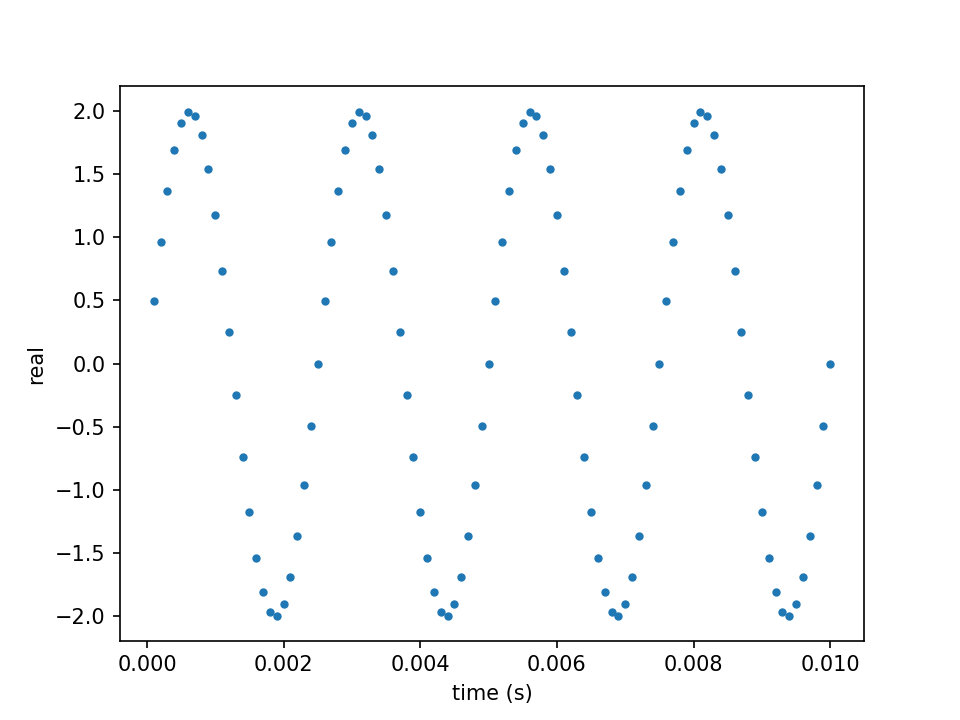

```python
fig = plt.figure()
ax = fig.add_subplot(111)
ax.plot(t[0:100], s[0:100], '.') # t 갯수 = s 갯수 해야 점 찍힘.
#대괄호X:모든벡터사용,대괄호OK:일부사용 (t,s)의 2차원 벡터 찍힘.
#점들 갯수 총 = 1000개
#(t, s 전체 사용하면 태극문양 안보이고 그냥 가로선 쭉쭉 그어짐)
ax.set_xlabel('time (s)')
ax.set_ylabel('real')
```

# 2.Generate signal by complex-phasor

```python
# generate parameter
amp = 2              # range [0.0, 1,0]
sr = 10000           # sampling rate, Hz
dur = 0.5            # in seconds
freq = 400.0         # sine frequency, Hz
```

```python
# generate time
t = np.arange(1, sr*dur+1)/sr
```

```python
# generate phase
theta = t * 2*np.pi*freq
theta
```

```
array([2.51327412e-01, 5.02654825e-01, 7.53982237e-01, ...,
       1.25613441e+03, 1.25638573e+03, 1.25663706e+03])
```

```python
# generate signal by complex-phasor
c = amp*np.exp(theta*1j)
c
```

```
array([1.93716632+4.97379774e-01j, 1.75261336+9.63507348e-01j,
       1.45793725+1.36909421e+00j, ..., 1.75261336-9.63507348e-01j,
       1.93716632-4.97379774e-01j, 2.        +1.57150938e-14j])
```

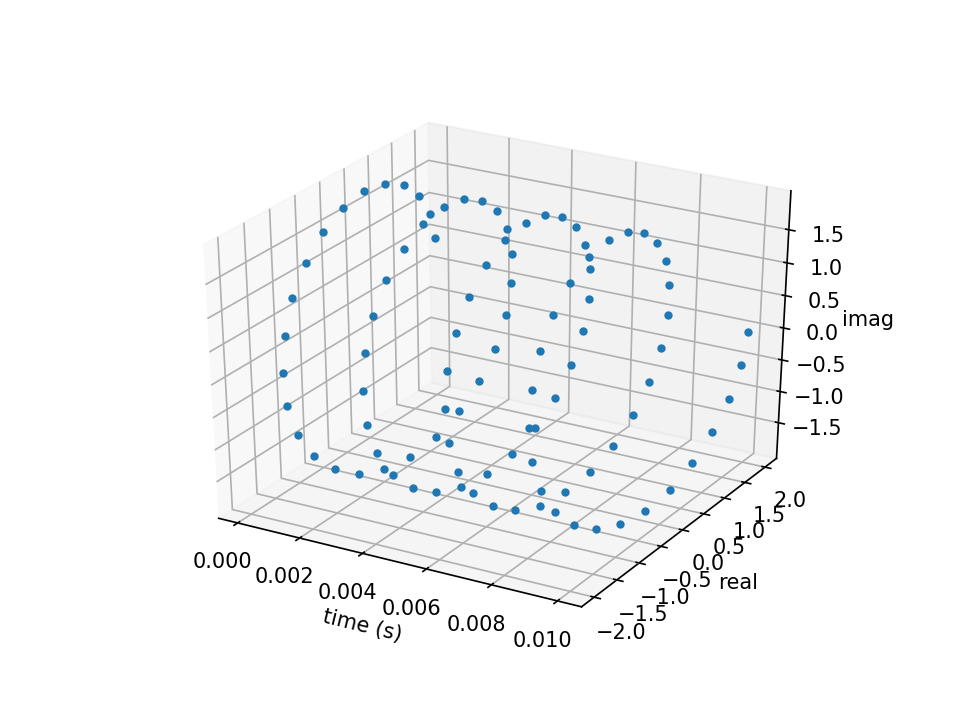

```python
fig = plt.figure() #figure 먼저 만들기
ax = fig.add_subplot(111, projection='3d') #회전체를 3d로
ax.plot(t[0:100], c.real[0:100], c.imag[0:100], '.')
#3d 답게 입력 3개 필요함 (저 한 점이 3차원 벡터 점)
ax.set_xlabel('time (s)')
ax.set_ylabel('real')
ax.set_zlabel('imag')
```

```python
ipd.Audio(c.real, rate=sr)
```

[interactive chart not shown]

- Complex phasor 의 Amplitude(진폭크기) = 스프링(원)의 반지름 길이

▷ 직경:4, 반지름:2(amp:2)

# 3.Generate pulse train

-plot 으로 여러 다른 harmonix 만들어서 성대에서 나오는 소리와 똑같은 소리 생성.

1.F0: 가장 낮은 ferq 최소에 해당하는 harmonix 의 freq 정하기 (sin wave의 하나 정하기)

2.F0 가지고 sin wave 만들기

3.배음 구조 만들어서 더하기: 앞에서 설정한 freq(ex:150hz)의 *2(300hz),* 3(450hz) 이렇게 ~

※ sr 과 hz 같이가는 부분 있다. (중요!)

ex) sr= 100hz 가 있다고 생각하자 → 표현할 수 있는 숫자의 개수가 1초에 100개.

Q) 이 100개의 숫자를 가지고 1hz의 freq를 표현할 수 있을까?

A) 가능. (태극문양을 그리며 1번의 sin wave 주기 왔다갔다 하면 됨)

Q) 2hz는 가능?

A) 가능. 두번 왔다갔다 하면 됨.

Q) 10000hz (100개의 숫자가 있는데 1초에 10000번 왔다갔다하게 가능?)

A) 불가능!

▶sr 이 1초에 충분히 있어야 그만큼의 주파수를 표현할 수 있다.

▶sr 의 1/2에 해당하는 nyquist frequency까지가 이 숫자상으로 표현할 수 있는 freq의 maximum.

ex) 박쥐가 내는 소리를 녹음기에는 들어오는데 CD로 표현은 안됨(너무 고주파여서) (사람이 내는 2만보다 높은 주파수를 초음파라고 함)

▷소리가 나는데 녹음기를 갖다대면 sr이 낮다면 녹음이 안될 것. 그걸 capture하고싶으면 sr을 우리가 표현하고자 하는 것의 2배보다 높게 해야됨.

< Generate pulse train >

*Sin wave를 여러가지 만들어 낼 건데, 제일 낮은 freq(100hz) 를 어디까지 올릴 수 있을까? → sr의 1/2까지만 올릴 수 있다.

-Fend:마지막 freq (sr의 1/2가 nyquist freqency)

-int:소수점나오면 지저분하니까 int로 반올림처리

-(time 은 위에서 이미 만들어놓음)

*phasor 만들때

- time 만들기
- radian(theta)를 time으로부터 만들기
- 그걸 sin에다 입력하기

→이 과정을 freq만 바꾸어주면서 여러번 반복하는게 pulse train 만들기의 핵심이다.

*for loop 에서 freq만 바뀌면서 반복적으로 돌아가는 게 포인트.

-range: (for loop돌때 range가 포인트): F0부터 Fend까지 가는데 100만큼 올라가면서 간다. 100 200 300 400~5000 부분이 range에 들어있다.

-총 50번의 loop이 돌아감.

*freq을 하나 둘 셋 넷...

*Theta 만들기 (time 다음으로 만드는 부분): 가 한번은 100hz, 두번째는 200hz, ...이렇게 들어와서 이 phasor 만들어줌 (→이 theta값을sin에다 넣음) (→이 값을 s로 받아 계속 반복적으로 더하고~더하고~해서 s만듦)

※문제: 제일 처음에 F0이 들어올때 정의된 s값이 없다(error). 따라서 처음 loop의 s를 미리 정의 해 주어야 함.

→s = np.zeros(len(t)) : 초기의 s값 정의.얼만큼 0을 만드냐면, 위에서 만든 time vector의 갯수만큼 0을 만들어 준다. →이제 sin wave에 더하고~

*s(signal): 변수에다 더하고~ 그다음거 더하고~ 한거 쓴 부분. 제일 처음 s가 있다면 지금 phasor 만든걸 더하고, 그걸 또 s자리에 넣어라~ 계속 old s new s update 교체하면서 ...

▶100~5000까지 다 돌면(더해지면) s가 다 더해진 상태로 남아있을 것. → 그 s를 맨 밑에서 plot하기 →다 할 순 없어서 [0:1000] 까지로 범위 한정 → x축:time, y축:더해진 s값 → fig 생김

▶밑에서 나오는 소리는 여러 sin wave를 harmonix로 다 합해서 만든거.

▶왜 pulse train?: sin wave의 부드러웠던 부분이 점점점 없어짐 → 만약 sr을 끝없이 올렸다면 sin wave 부드러운 부분 더 밑으로 들어가고 아예 없어져서 0이 될 것 → 결과적으로 선 하나, 0000 ~ 과 같은 그림 생김 → pulse train.

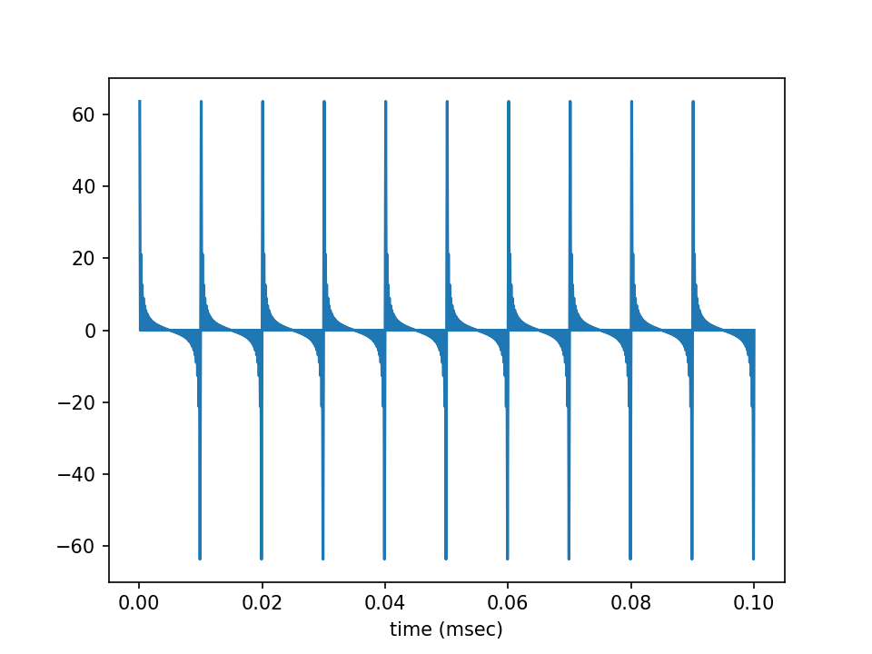

[interactive chart not shown]

```python
# generate samples, note conversion to float32 array
F0 = 100; Fend = int(sr/2); s = np.zeros(len(t));
for freq in range (F0, Fend+1, F0): #For loop을 통해 여러번 반복
    theta = t * 2*np.pi * freq  #sin입력할 theta만들기
    s = s + amp * np.sin(theta) #sin에다 입력하기. #(amp적기)
                                #(complex/cos 써도 마찬가지)
fig = plt.figure()
ax = fig.add_subplot(111)
ax.plot(t[0:1000], s[0:1000]);
ax.set_xlabel('time (msec)')
ipd.Audio(s, rate=sr)
```

※주의) 이 그림은 pulse train이지 절대 spectrum이 아니다!! 이 그림에서 한 time point에서의 spectrum(어떤 freq성분이 많은지 보여주는거) → 이 spectrum이 100hz, 200hz, 300hz ... 이어진 그림을 만들고, 그걸 decreasing하게 만들고, 거기에서 formant 을 carving 해야 함!

# <Part 13>

-지금까지 wave에 대해 배움. 이게 차곡차곡 쌓여서 성대에서 나는 소리 만들어짐. sr half hz 까지 freq가능이고 freq 점점 증가 더해져서 pulse train.

*Waveform) x축: time, y축: value/energy

*Spectrogram) x축: time, y축: frequency (freq의 관점에서 보기!!어떤 freq 성분대가 많은지!!)

< spectrum >

: pulse train은 sin wave 여러가지 합친 상태 → 한 칸 slice 잘랐다고 생각 (어차피 변하지 x, 어느 시점에서 자르나 OK) → 한 시점에서 어떤 frequency 성분이 많은가?

< spectrogram >

: spectrum(한 순간의 frequency 성분)을 시간축으로 쭉 나열한 것.

# 1. Formant 만들기

*Formant: 100hz, 200hz, 300hz ~ 5000hz Spectrum이 쭉 나열되어 있을 때, 점점 내려가는 산맥 모양(산맥의 특성에 따라 모양 다양)의 도장을 찍는 것. (F1 & F2 가 모음 구별에 핵심 역할)

1. frequency의 amplitude를 gradually decreasing 으로 만들어주기
2. 산맥 하나하나 만들어주기 (점점 내려가는 모양으로) (이 작업으로 성대 소리 → 아/이 소리처럼 만들어짐)

< 기본값들 설정 다시해주기> - Phasor 부터

```python
from matplotlib import pyplot as plt
from mpl_toolkits.mplot3d import Axes3D
from mpl_toolkits.axes_grid1 import make_axes_locatable
import IPython.display as ipd
import numpy as np
%matplotlib notebook
from scipy.signal import 1filter
```

```
  File "<ipython-input-115-2b2f5e74b005>", line 7
    from scipy.signal import 1filter
                             ^
SyntaxError: invalid syntax
```

```python
# parameter setting
amp = 1           # range [0.0, 1.0]
sr = 10000        # sampling rate, Hz
dur = 0.5         # in seconds
freq = 440.0    # sine frequency, Hz  #배수로하면 모두 같은 음(라)
```

```python
# generate time
t = np.arange(1, sr * dur+1)/sr
```

```python
# generate phase (time 으로부터 각도 만들기)
theta = t * 2*np.pi * freq
```

```python
# generate signal by cosine-phasor (sin 함수에 통하게)
s = amp*np.sin(theta)
```

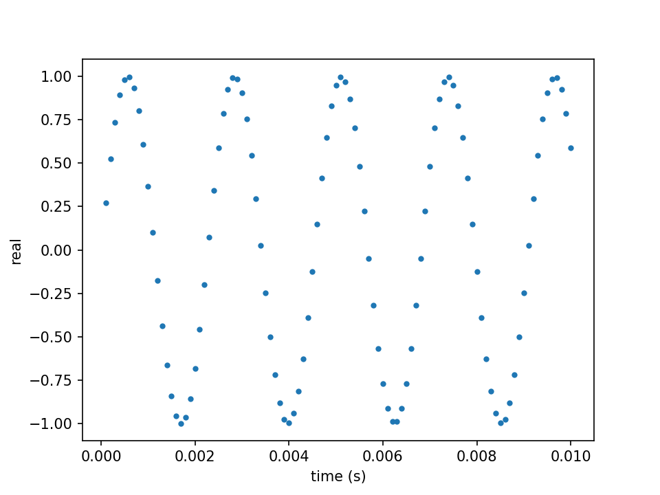

```python
fig = plt.figure()
ax = fig.add_subplot(111)
ax.plot(t[0:100], s[0:100], '.')
ax.set_xlabel('time (s)')
ax.set_ylabel('real')
#0.5초 만들었는데 0.01초까지 표시해줌
```

```python
ipd.Audio(s, rate=sr)
```

[interactive chart not shown]

```python
# generate signal by complex-phasor #theta 들어가는거 빼고 sin 똑같
c = amp*np.exp(theta*1j)
c
```

[output not shown]

*Complex phasor 실행 → complex 값들 나오고 이를 c라고 명명.

Complex number(a+bi) 자체는 plotting이 안됨.→ a, b를 각각 x, y축으로 떨어뜨려서 2차원으로 plotting 가능.

(sin wave는 1차원)

[figure not shown]

```python
fig = plt.figure()
ax = fig.add_subplot(111, projection='3d')
ax.plot(t[0:100], c.real[0:100], c.imag[0:100], '.')
ax.set_xlabel('time (s)')
ax.set_ylabel('real')
ax.set_zlabel('imag')
```

```python
ipd.Audio(c.real, rate=sr)
#s를 playout 하기 #freq 배수면 옥타브 바뀜
#real값만 (Cos)
#Sin을 phasor으로 썼으면 sin인 imag 넣어야 됨. (sin소리=cos소리)
```

[interactive chart not shown]

```python
# generate signal by cosine-phasor (sin 함수에 통하게)
s = amp*np.sin(theta)
```

-소리 또한 cos 라 = sin 라

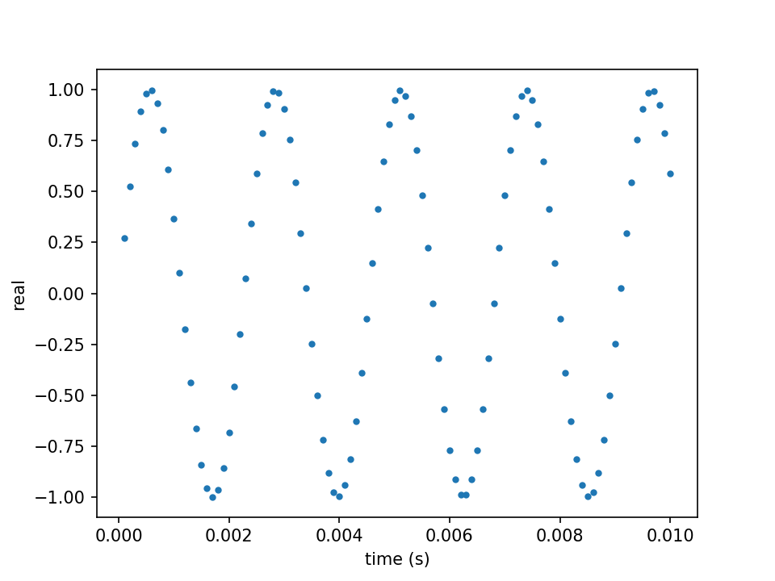

```python
fig = plt.figure()
ax = fig.add_subplot(111)
ax.plot(t[0:100], s[0:100], '.')
ax.set_xlabel('time (s)')
ax.set_ylabel('real')
#0.5초 만들었는데 0.01초까지 표시해줌
```

< Sin, Cos 관계 >

-Sin 과 Cos 은 shape은 똑같지만 단지 살짝 이동한 모양새이다. 얼만큼 이동하면 sin이 될까?

-1/2ㅠ(90도) 차이!

-Sin을 하든 Cos을 하든 소리가 전혀 바뀌지 않음.

Q)만약 1/8ㅠ 이동하면 소리가 바뀔까?

A)안 바뀐다. 각도(phasor) 차이는 우리 귀가 인식 X. 인간의 귀는 Freq 변화만 느낄 수 있다.

# 2.Function 만들기

```python
def hz2w(F, sr):    #def 뒤에는 이름,(쓰고싶은 입력 하나하나 적기)
    NyFreq = sr/2;
    w = F/NyFreq *np.pi;
    return w        #return: 이부분이 출력

def resonance (srate, F, BW):   #BW: band width
    a2 = np.exp(-hz2w(BW, srate))  #여기서 위에함수 또 불러옴
                                   #그래서 resonance 만 쓰면 됨.
    omega = F*2*np.pi/srate
    a1 = -2*np.sqrt(a2)*np.cos(omega)
    a = np.array([1, a1, a2])
    b = np.array([sum(a)])
    return a, b     #출력이 2개
```

→ 0 중심으로 하는 큰 산 만든다고 생각 (0보다 작은 부분은 안보임)

→ 뚱뚱하게 만들어야 잘랐을 때 완만한 곡선이 생길 것.

```python
RG = 0    # RG is the frequency of the Glottal Resonator
BWG = 100   # BWG is the bandwidth of the Glotal Resonator
a, b=resonance(sr,RG,BWG) #sr, 산맥의 위치, 산맥의 뚱뚱/뾰족도
s = lfilter(b, a, s, axis=0)
ipd.Audio(s, rate=sr)
```

[interactive chart not shown]

- < RG > spectrum에서 크기 똑같은 100, 200, 300 hz ... 여기에서 gradually decreasing 하는거 만들어야 함.
- < F0 만들기 >

→ 0 중심으로 하는 큰 산 만든다고 생각 (0보다 작은 부분은 안보임)

→ 뚱뚱하게 만들어야 잘랐을 때 완만한 곡선이 생길 것.

→ Praat으로 봤을 때 F1 아래쪽(저주파)가 amp가 확실히 크고 산맥이 고주파(위)로 갈수록 점점 흐려짐

- <F1 만들기>

→ BWG 조금 더 홀쭉해졌다.

```python
RG = 500    # RG is the frequency of the Glottal Resonator
BWG = 60   # BWG is the bandwidth of the Glotal Resonator
a, b=resonance(sr,RG,BWG) #sr, 산맥의 위치, 산맥의 뚱뚱/뾰족도
s = lfilter(b, a, s, axis=0)
ipd.Audio(s, rate=sr)
```

[interactive chart not shown]

```python
RG = 1500    # RG is the frequency of the Glottal Resonator
BWG = 200   # BWG is the bandwidth of the Glotal Resonator
a, b=resonance(sr,RG,BWG) #sr, 산맥의 위치, 산맥의 shape
s = lfilter(b, a, s, axis=0)
ipd.Audio(s, rate=sr)
```

[interactive chart not shown]

```python
RG = 2500    # RG is the frequency of the Glottal Resonator
BWG = 200   # BWG is the bandwidth of the Glotal Resonator
a, b=resonance(sr,RG,BWG) #sr, 산맥의 위치, 산맥의 shape
s = lfilter(b, a, s, axis=0)
ipd.Audio(s, rate=sr)
```

[interactive chart not shown]

```python
RG = 3500    # RG is the frequency of the Glottal Resonator
BWG = 200   # BWG is the bandwidth of the Glotal Resonator
a, b=resonance(sr,RG,BWG) #sr, 산맥의 위치, 산맥의 shape
s = lfilter(b, a, s, axis=0)
ipd.Audio(s, rate=sr)
```

[interactive chart not shown]

(위 소리들) 입술 없을때의 소리

(아래 소리) 입술 있을때 - 소리 공명돼서 커짐

```python
s = lfilter(np.array([1, -1]), np.array([1]), s)
ipd.Audio(s, rate=sr)
```

[interactive chart not shown]

(여기까지 소리가 만들어졌다고 assume.)

# <Part 18>

*wavfile 이 필요한 이유: 외부에서 어떤 소리를 wavfile로 갖고 오고 싶을 때 쓰면 됨. 'a.wav'이란 파일 있으면! 근데 우리는 지금 위에서 만든 s를 쓸것임.

*이 vector의 size는?

*Complex wave: Frequency 별로 쪼개어서 원래 complex wave에다 각각 곱하기 → 그러면 성분이 얼마나 강한지 inner product 통하여 알 수 있음.

*nSamp = len(s): 그럴려면 s의 길이를 먼저 알아야 할 것임. → nSamp 의 크기에 맞춰서 phasor 똑같이 만들어서 Inner product 하려고. (sample 개수 중요!!!!!)

# Load wav

```python
from scipy.io import wavfile
# sr, s = wavfile.read('a.wav')
nSamp = len(s)
dur = nSamp / sr
t = np.linspace(1/sr, dur, nSamp)
```

# Fourier transform

*S: 우리가 분석하고자 하는 target wave이자 original signal.

*nSamp: target wave의 sample 개수(벡터 크기) 알기 (→이거랑 똑같이 phasor → inner product)

*nFFT: 위에서 만든 nSamp을 nFFT라고 이름 바꿈 (결국 똑같은거)

*For loop 사용: range(0, nFFT) → sample 갯수만큼 for loop을 돈다.

*z = np.exp(omega*1j)**(np.arange(0,nSamp)) : Complex wave 드는 줄, 즉 complex phasor 이용하는 줄.

- np:numpy
- amp: 각 freq 성분에 대한 energy 값
- exp: e (로그 base)
- omega: w (e의 지수)
- 1j: i (e의 지수)
- **: 지수를 의미.** 의 뒷부분에 있는게 통째로 지수로 올라간다. (ex: **3 = 3승) 즉, e의 wi승의 지수로 [0부터 100개의 vector]가 올라감
- Omega(w) = 2pi *n(for loop돌때 0~sample개수) / 100(nSamp=nFFT=100이라고 가정) → 예를 들어 첫번째 경우는 w = 2pi* 0/100 = 0

*z: complex wave를 loop의 갯수만큼 만드는 것. 0번째 부터 nSamp-1 개만큼 여러개 있음. 그것을 S와 각각 모두 inner product → 그것에 대한 결과값들이 각각 나올 것.

*s는 원래 있던 것, z는 for loop 할때마다 다른 값 나옴.

*Dot product: 마지막줄에서 s와 z를 매번 dot product한다.

*abs: 절댓값(absoulte). dot product 해서 a+bi의 complex 값이 나온다 치더라도 → absoulte 값을 취하면 실수로 바뀐다. (원점으로부터 그 complex의 길이와 같음).

*abs 취하기 → complex 의 크기값을 알 수 있다.

*처음에 amp라고 빈 거 만들어놓았는데, 마지막줄의 amp.append의 값을 for loop돌 때마다 amp variable에 넣어주자. → 다 끝나고 나면 amp에 들어있는 건 loop의 크기(횟수)만큼.

▷ for loop이 끝나고 난 뒤 amp의 크기/길이 = loop가 도는 횟수

▷ Amp 에는 절대 허수가 들어갈 수 없다. (이전에 절댓값 취했기 때문에)

→이제 Amp plotting만 남음!

```python
nFFT = nSamp
amp = [];
for n in range(0, nFFT):
    omega = 2*np.pi*n/nFFT   # angular velocity
    z = np.exp(omega*1j)**(np.arange(0,nSamp))
    amp.append(np.abs(np.dot(s,z)))
```

< Amp plotting >

*Y축(amp): 각 freq 성분에 대한 energy 값인 amp은 위에서 만듦.

-Plotting 할때 점점 에 해당하는 y값들을 알아냄. 그런데 y에 해당하는 x좌표가 뭔지는 아직 모름.

*numpy에서 range 만들어주기: sample 갯수가 100이라고치면 +1을 해야 100까지 포함됨. 그래서 nFFT+1 → 거기에다 sr곱해주기 → 또 sample 갯수(100개)로 나누어주기 → [10000/100 ~ 10000] 즉 [100 ~ 10000]. → 처음부터 sample 이 1~100이었기 때문에 [100 ~ 10000]도 100개!

< Spectrum >

*X축 : sr=10000 을 range로 하고 있다.

*양쪽이 대칭 (나머지 오른쪽 5000~10000hz까지는 필요가 없으며, 이 그래프에서 3000hz나 7000hz나 해당되는 기능,숫자 똑같음. (원래 sr로는 그 1/2의 주파수까지만 표현할 수 있기 때문에 그러하다.)

*따라서 사실상 왼쪽 반 (0~5000hz)까지가 한 순간의 spectrum 이라고 생각하면 된다.

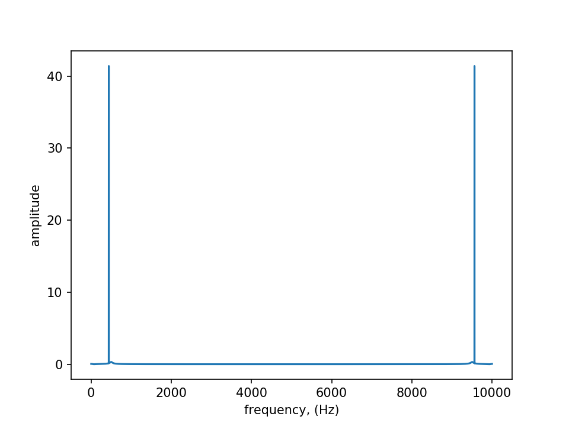

```python
fig = plt.figure()
ax = fig.add_subplot(111)
freq = np.arange(1,nFFT+1)*sr/nFFT;
ax.plot(freq, amp)
ax.set_xlabel('frequency, (Hz)')
ax.set_ylabel(' amplitude ')
```

(계속 똑같은 소리 나옴)

x축: 0 ~ 10000

※시간축이 아니라 한 given time의 주파수 축인것에 주의하자!!! (시간축을 보고싶으면 spectrogram. 위로 세워서 오른쪽으로 쭉~하면 spectrogram)

*하나의 bar: 하나의 inner product & 절댓값 한 값

*bar의 갯수 = sample 의 갯수 (sample의 갯수만큼 for loop 돌아서 그만큼 bar이 생긴다)

*왼/오 대칭구조

*(이유)sr의 1/2까지만 의미가 있다. 5000부터 10000까지는 대칭으로 중복됨.

*Spectral analysis → 저 half을 spectrum 이라고 부름 (각 freq 성분들을 probing/inner product해서 나온 absolute 값)

*그럼 저런 결과값이 어떤 의미를 가질까?

*처음에 resonance 써서 gradually decreasing 하게 안만들었다면 저 낮아지는 그래프가 flat 하게 생겼었을 것. (이퀄라이저 같은거)

*이 그래프를 보고 freq의 energy가 얼만큼 있느냐를 수치적 visualize로 알 수 있다!!

*ex)베이스 악기같은거 100 sample 가져오면 비슷하게 나타남 → 바이올린같이 음역대 높은 악기는 더 오른쪽에 산 시작할 것.

< Spectrogram >

*spectrogram은 3차원, 여러개의 색깔로 구분. (2차원의 spectrum이 세워지고 여러개가 합쳐져서 펴진게 spectrogram이다.)

*한순간의 spectrum을 여러개 이어보자!

Q) Spectrogram의 어떤 부분이 spectrum에 해당할까?

-한 timepoint에서 한장만 잘랐다고 생각하자 → 아주 진하게 산맥이 올라가다가 다시 내려가고, 다시 올라가고... 그리고 y축은 아래쪽으로 갈수록 저주파고 위로 갈수록 고주파이다.

-spectrum에서 올라가는 부분이 spectrum에서 까맣게 칠해진다

-spectrum은 한 장, 이게 시간상으로 쌓여서 spectrogram 만듦.

# < Part 19 >

# define helper functions

```python
def frame_signal(signal, srate, win_size, win_step):
    frame_size = int(win_size * srate)
    frame_step = int(win_step * srate)

    # Get number of frames
    num_frames = int(np.ceil(np.abs(len(signal) - frame_size) / frame_step))
    # Pad signal
    pad_len = num_frames * frame_step + frame_size
    pad = np.zeros((pad_len - len(signal)))
    signal_padded = np.append(signal, pad)
    # Get within-frame sample indices
    idx1 = np.tile(np.arange(0, frame_size), (num_frames, 1))
    # Get vectors of frame_step increments
    idx2 = np.tile(np.arange(0, num_frames * frame_step, frame_step),
                   (frame_size, 1)).T
    # Get total indices divided by each frame
    indices = idx1 + idx2
    # Get frames divided by each frame based on indices
    frames = signal_padded[indices.astype(np.int32, copy=False)]
#     if cutoff is not None:
#         cutoff_bin = round(cutoff * nfft / (srate))  # hz -> bin
#         frames = frames[:, :cutoff_bin]
    return frames

def get_window(win_size, srate, win_type, win_samp=None):
    '''Get window samples for win_size'''
    if win_samp is None:
        win_samp = int(win_size * srate)  # sec -> sample

    if win_type == 'rect':
        return np.kaiser(win_samp, 0)
    elif win_type == 'hamming':
        return np.hamming(win_samp)
    elif win_type == 'hanning':
        return np.hanning(win_samp)
    elif win_type == 'kaiser':
        return np.kaiser(win_samp, 14)
    elif win_type == 'blackman':
        return np.blackman(win_samp)

def plot_spectrogram(S):
    fig, ax = plt.subplots(facecolor='white', figsize=(14, 6))
    im = ax.imshow(S.T, aspect='auto', origin='lower', cmap=plt.get_cmap('Greys'))
    divider = make_axes_locatable(ax)
    cax = divider.append_axes('right', size='5%', pad=0.05)
    cbar = fig.colorbar(im, cax=cax)
    return fig, ax

def preemphasis(s, pre_emp=0.97):
    # Emphasize high frequency range of the waveform by increasing power(squared amplitude).
    s = lfilter([1, -pre_emp], [1], s)
    return s
```

# preprocessing signal

*spectrogram 에 해당하는 부분이 나옴 (물론 훨씬 간단함. 간단한게 보이지만 어쨋든 spectrogram)

*(아래부분 주목) : Wave라는게 길게 있는데, 이 때 이걸 우리가 "프리에 분석"이라고 해서 Spectrum을 해서 빵 넣으면 한장짜리 스펙트럼이 나올건데, 그거를 어떻게 여러 장이 연결된 Spectrogram으로 만들어낼까?

< Spectrum → Spectrogram 만들어내기 >

-"령도자~"처럼 긴 wave가 있다고 했을 때, 앞부분 조금만 자르자.

1.앞부분에서 조금만 자르자 → spectrum 만들기.

2.조금 뒤로 이동해서 또 조금만 자르자 → 또 spectrum 만들기. (한장한장씩)

3.앞에서 만든 spectrum 들을 모두 모아 compationate 한 게 Spectrogram.

*spectrum 한장한장씩 만들 때, 과연 처음 만들 때 얼만큼의 vector을 가지고 dot product을 할까? 그 "얼마만큼"의 size가 win_size.

*win_size (window size): spectrum 한장한장씩 만들 때, 과연 처음 만들 때 얼만큼의 vector을 가지고 dot product을 할까? 그 "얼마만큼"의 size가 바로 win_size. 여기서는 0.008초, 즉 1000분의 8초.

*win_step: 한장 만들고 다음 칸으로 이동할 때, 얼마나 이동할지에 관한 정보. 여기서는 0.001초, 즉 1000분의 1초. (1000분의 1초 이동하고, 또 analysis 하고... 이런 과정이다.)

→→이게 compationate 되면 = Spectrogram 만들어진다.

→→(저 과정을 한번만 했다면 = Spectrum, 여러 번 해서 모으면 = Spectrogram. )

```python
max_freq = None  # cutoff freq
win_size = 0.008 # sec
win_step = 0.001  # sec
win_type = 'hanning' # options: 'rect', 'hamming', 'hanning', 'kaiser', 'blackman'
nfft = 1024

# Emphasize signal
s = preemphasis(s)
# Frame signal
frames = frame_signal(s, sr, win_size, win_step)
# Apply window function
frames *= get_window(win_size, sr, win_type)
print('frames:', frames.shape)
```

```
frames: (492, 80)
```

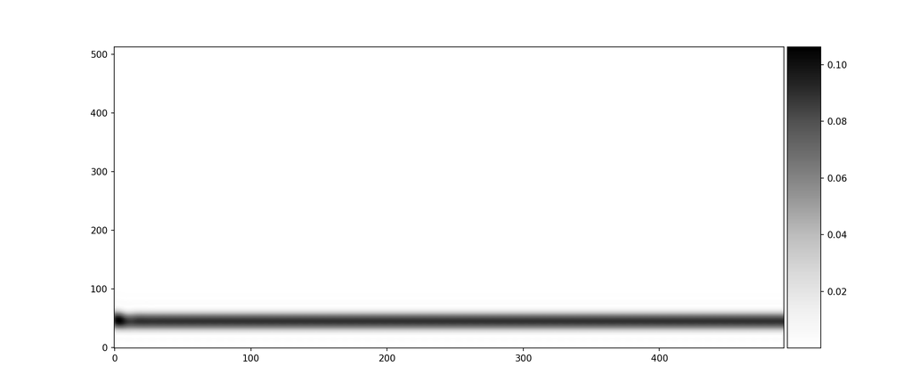

[output not shown]

```python
magspec = np.abs(np.fft.rfft(frames, n=nfft)) # frames x (nfft//2 + 1)
plot_spectrogram(magspec)
```

(위) 원래 값.

- Spectrum에서 저주파 부분이 강하고 고주파 부분이 약한 게 Spectrogram 에도 그대로 반영되어 있다.

-첫번째만 진하게(아래), 위로 갈수록 산맥이 더욱 옅어짐(흐려짐)

Q1)그런데 수업시간에 본 "령도자~" spectrogram은 위쪽도 진하게 되어있다?

A1)그냥 하면 위쪽이 너무 희미해서 처리를 가해준 것.

Q2)어떤 처리?

A2)"Power Spectrum" → "Log10 취하기"

< Power Spectrum >

-Complex number로 다 product 나오는 것 → 거기서 절댓값 취해서 실수로 만들어주고 → 그걸 저 한장에 plotting.

-어떤 값들이 나오냐?

→ 이 값들을 한번 제곱해주기 → 진한 부분은 더 진해지고(1보다 큰 값들은 훨씬 커지고) 약했던 부분은 더 약해진다. (1보다 작은 값들은 제곱하면 훨씬 작아진다.)

< Log 취하기 >

Q)그렇다면 이 작업을 하는 이유는?

A)로그를 취하기 위해서이다.

→이 작업을 하면 1보다 큰 값은 엄청나게 커지고, 1보다 작은 값은 엄청나게 0에 가까워짐.

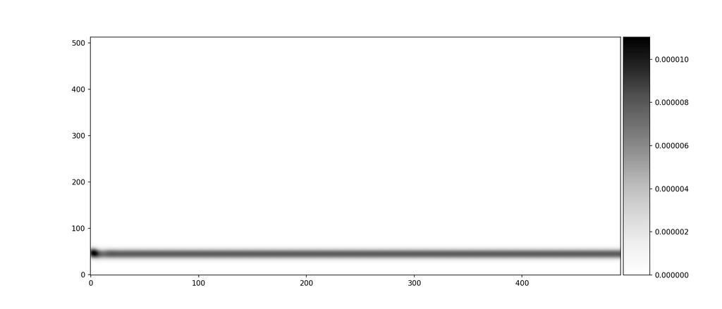

```python
powspec = 1/nfft * (magspec**2)
#원래 값 제곱 (**2) :
#→1보다 크면 훨씬 크게, 1보다 작으면 훨씬 더 0에 가깝게 바뀜.
plot_spectrogram(powspec);
```

< Log 취하기 >

: 엄청 극단적인 숫자들을 비교적 다루기 쉬운 숫자로 바꾸어 표현할 수 있다. (덜 부담스럽게, 다룰 수 있는 범위 내에 숫자가 골고루 퍼져 있게 된다. )

-엄청나게 커진 값에 log10을 취하면 ex)10000 → 10의 4승 →: 4

< Power spectrum → Log 취하기의 효과 >

: 물론 아래의 spectrogram 도 위로 갈수록 희미해지는 건 마찬가지이지만, 산맥이 너무 급하게 고주파→저주파로 낮아지는 건 방지할 수 있다. 고주파로도 더 뚜렷하게 visualize 할 수 있다.

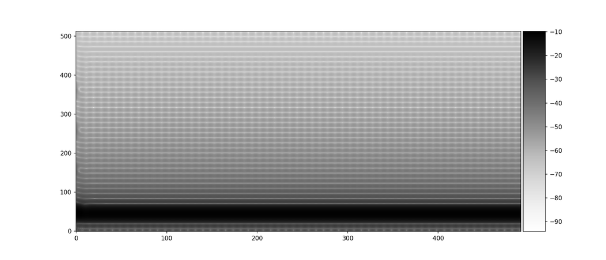

```python
logspec = 10 * np.log10(magspec) # dB scale
plot_spectrogram(logspec);
```

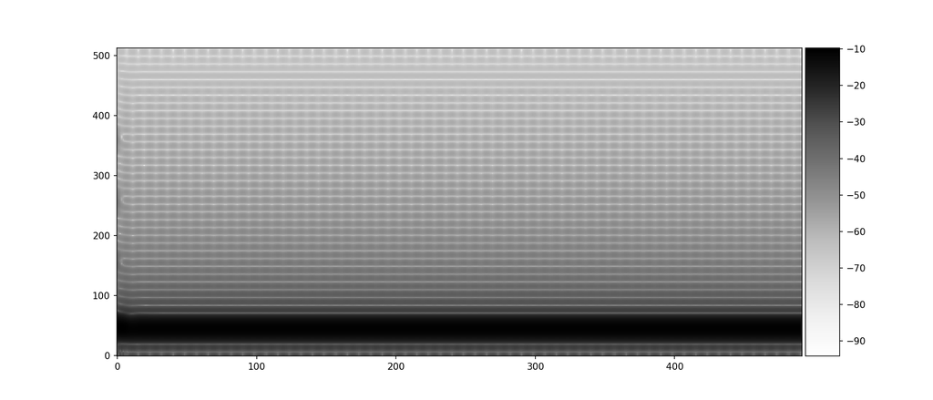

```python
logspec = 10 * np.log10(magspec) # dB scale
plot_spectrogram(logspec);
```